# Prosper Loan Data - Part I

## by Oluwafunmito Blessed ODEFEMI

## Introduction

> The Prosper loan data set contains 113,937 loans with 81 variables on each loan, including loan amount, borrower rate (or interest rate), current loan status, borrower income, and many others. We are interested in drawing out as many interesting insights as possible using univaraite, bivariate, and multivariate analysis and visualization.

## Preliminary Wrangling

```python
# import all packages and set plots to be embedded inline
import numpy as np
import pandas as pd
import matplotlib.pyplot as plt
import seaborn as sns

%matplotlib inline
```

```python
# read data set into pandas DataFrame
prosper_dataset = pd.read_csv("prosperLoanData.csv")

# get a general overview of the data set.
prosper_dataset.shape
```

```
(113937, 81)
```

```python
# get information on the dataset's features and completeness

prosper_dataset.info()
```

```
<class 'pandas.core.frame.DataFrame'>
RangeIndex: 113937 entries, 0 to 113936
Data columns (total 81 columns):
 #   Column                               Non-Null Count   Dtype
---  ------                               --------------   -----
 0   ListingKey                           113937 non-null  object
 1   ListingNumber                        113937 non-null  int64
 2   ListingCreationDate                  113937 non-null  object
 3   CreditGrade                          28953 non-null   object
 4   Term                                 113937 non-null  int64
 5   LoanStatus                           113937 non-null  object
 6   ClosedDate                           55089 non-null   object
 7   BorrowerAPR                          113912 non-null  float64
 8   BorrowerRate                         113937 non-null  float64
 9   LenderYield                          113937 non-null  float64
```

[output cut: 73 more lines]

```python
# get random sampe of dataset

prosper_dataset.sample(10)
```

|  | ListingKey | ListingNumber | ListingCreationDate | CreditGrade | Term | LoanStatus | ClosedDate | BorrowerAPR | BorrowerRate | LenderYield | ... | LP_ServiceFees | LP_CollectionFees | LP_GrossPrincipalLoss | LP_NetPrincipalLoss | LP_NonPrincipalRecoverypayments | PercentFunded | Recommendations | InvestmentFromFriendsCount | InvestmentFromFriendsAmount | Investors |
| --- | --- | --- | --- | --- | --- | --- | --- | --- | --- | --- | --- | --- | --- | --- | --- | --- | --- | --- | --- | --- | --- |
| 46159 | B5FB348594719244427B0FC | 462328 | 2010-06-13 07:08:50.627000000 | NaN | 36 | Completed | 2013-12-30 00:00:00 | 0.33097 | 0.2950 | 0.2850 | ... | -35.25 | 0.0 | 0.00 | 0.00 | 0.0 | 1.0 | 0 | 0 | 0.0 | 35 |
| 81917 | 56F03390726402205C4F164 | 147487 | 2007-06-06 04:39:58.487000000 | C | 36 | Chargedoff | 2008-06-15 00:00:00 | 0.29776 | 0.2900 | 0.2800 | ... | -146.62 | 0.0 | 21951.10 | 21933.70 | 0.0 | 1.0 | 0 | 0 | 0.0 | 209 |
| 97664 | 87473593448868465EE9951 | 1030929 | 2013-11-11 10:55:20.243000000 | NaN | 60 | Current | NaN | 0.21115 | 0.1870 | 0.1770 | ... | -37.23 | 0.0 | 0.00 | 0.00 | 0.0 | 1.0 | 0 | 0 | 0.0 | 1 |
| 107839 | BFE33587507307752A4BACA | 888273 | 2013-09-05 16:01:37.460000000 | NaN | 36 | Current | NaN | 0.31032 | 0.2712 | 0.2612 | ... | -16.05 | 0.0 | 0.00 | 0.00 | 0.0 | 1.0 | 0 | 0 | 0.0 | 29 |
| 59363 | F5FF3579022256746145B9A | 774015 | 2013-05-08 18:47:09.327000000 | NaN | 60 | Current | NaN | 0.20081 | 0.1769 | 0.1669 | ... | -72.31 | 0.0 | 0.00 | 0.00 | 0.0 | 1.0 | 0 | 0 | 0.0 | 1 |
| 33843 | D7B53601896238808A1578A | 1193207 | 2014-02-14 05:53:27.880000000 | NaN | 36 | Current | NaN | 0.12117 | 0.0930 | 0.0830 | ... | 0.00 | 0.0 | 0.00 | 0.00 | 0.0 | 1.0 | 0 | 0 | 0.0 | 1 |
| 16566 | 1CF93399896040134488434 | 199879 | 2007-09-10 10:46:05.807000000 | D | 36 | Chargedoff | 2008-11-03 00:00:00 | 0.18475 | 0.1775 | 0.1675 | ... | -30.87 | 0.0 | 4106.92 | 4106.92 | 0.0 | 1.0 | 0 | 0 | 0.0 | 166 |
| 52128 | FBFC3507042071489F0746B | 493263 | 2011-02-09 09:24:46.263000000 | NaN | 60 | Completed | 2012-03-06 00:00:00 | 0.18915 | 0.1749 | 0.1649 | ... | -120.00 | 0.0 | 0.00 | 0.00 | 0.0 | 1.0 | 0 | 0 | 0.0 | 313 |
| 22827 | FB9A3534284455007B9FD2C | 544504 | 2011-12-13 10:13:56.453000000 | NaN | 36 | Current | NaN | 0.19108 | 0.1621 | 0.1521 | ... | -76.08 | 0.0 | 0.00 | 0.00 | 0.0 | 1.0 | 0 | 0 | 0.0 | 94 |
| 46271 | 6A2E33767314400493604DB | 76053 | 2006-12-18 15:53:52.733000000 | C | 36 | Completed | 2008-09-11 00:00:00 | 0.13654 | 0.1295 | 0.1245 | ... | -18.78 | 0.0 | 0.00 | 0.00 | 0.0 | 1.0 | 0 | 0 | 0.0 | 85 |

10 rows × 81 columns

```python
# Generate random dataset and seed for reproducibility.
np.random.seed(5000)
sample = np.random.choice(prosper_dataset.shape[0], 2000, replace=False)
prosper_data_rand = prosper_dataset.loc[sample]
```

```python
#  summary statistics of numerical variables

prosper_dataset.describe().style.format("{0:,.3f}")
```

|  | ListingNumber | Term | BorrowerAPR | BorrowerRate | LenderYield | EstimatedEffectiveYield | EstimatedLoss | EstimatedReturn | ProsperRating (numeric) | ProsperScore | ListingCategory (numeric) | EmploymentStatusDuration | CreditScoreRangeLower | CreditScoreRangeUpper | CurrentCreditLines | OpenCreditLines | TotalCreditLinespast7years | OpenRevolvingAccounts | OpenRevolvingMonthlyPayment | InquiriesLast6Months | TotalInquiries | CurrentDelinquencies | AmountDelinquent | DelinquenciesLast7Years | PublicRecordsLast10Years | PublicRecordsLast12Months | RevolvingCreditBalance | BankcardUtilization | AvailableBankcardCredit | … |
| --- | --- | --- | --- | --- | --- | --- | --- | --- | --- | --- | --- | --- | --- | --- | --- | --- | --- | --- | --- | --- | --- | --- | --- | --- | --- | --- | --- | --- | --- | --- |
| count | 113,937.000 | 113,937.000 | 113,912.000 | 113,937.000 | 113,937.000 | 84,853.000 | 84,853.000 | 84,853.000 | 84,853.000 | 84,853.000 | 113,937.000 | 106,312.000 | 113,346.000 | 113,346.000 | 106,333.000 | 106,333.000 | 113,240.000 | 113,937.000 | 113,937.000 | 113,240.000 | 112,778.000 | 113,240.000 | 106,315.000 | 112,947.000 | 113,240.000 | 106,333.000 | 106,333.000 | 106,333.000 | 106,393.000 | … |
| mean | 627,885.693 | 40.830 | 0.219 | 0.193 | 0.183 | 0.169 | 0.080 | 0.096 | 4.072 | 5.950 | 2.774 | 96.072 | 685.568 | 704.568 | 10.317 | 9.260 | 26.755 | 6.970 | 398.292 | 1.435 | 5.584 | 0.592 | 984.507 | 4.155 | 0.313 | 0.015 | 17,598.707 | 0.561 | 11,210.225 | … |
| std | 328,076.236 | 10.436 | 0.080 | 0.075 | 0.075 | 0.068 | 0.047 | 0.030 | 1.673 | 2.377 | 3.997 | 94.481 | 66.458 | 66.458 | 5.458 | 5.023 | 13.638 | 4.631 | 447.160 | 2.438 | 6.430 | 1.979 | 7,158.270 | 10.160 | 0.728 | 0.154 | 32,936.402 | 0.318 | 19,818.361 | … |
| min | 4.000 | 12.000 | 0.007 | 0.000 | -0.010 | -0.183 | 0.005 | -0.183 | 1.000 | 1.000 | 0.000 | 0.000 | 0.000 | 19.000 | 0.000 | 0.000 | 2.000 | 0.000 | 0.000 | 0.000 | 0.000 | 0.000 | 0.000 | 0.000 | 0.000 | 0.000 | 0.000 | 0.000 | 0.000 | … |
| 25% | 400,919.000 | 36.000 | 0.156 | 0.134 | 0.124 | 0.116 | 0.042 | 0.074 | 3.000 | 4.000 | 1.000 | 26.000 | 660.000 | 679.000 | 7.000 | 6.000 | 17.000 | 4.000 | 114.000 | 0.000 | 2.000 | 0.000 | 0.000 | 0.000 | 0.000 | 0.000 | 3,121.000 | 0.310 | 880.000 | … |
| 50% | 600,554.000 | 36.000 | 0.210 | 0.184 | 0.173 | 0.162 | 0.072 | 0.092 | 4.000 | 6.000 | 1.000 | 67.000 | 680.000 | 699.000 | 10.000 | 9.000 | 25.000 | 6.000 | 271.000 | 1.000 | 4.000 | 0.000 | 0.000 | 0.000 | 0.000 | 0.000 | 8,549.000 | 0.600 | 4,100.000 | … |
| 75% | 892,634.000 | 36.000 | 0.284 | 0.250 | 0.240 | 0.224 | 0.112 | 0.117 | 5.000 | 8.000 | 3.000 | 137.000 | 720.000 | 739.000 | 13.000 | 12.000 | 35.000 | 9.000 | 525.000 | 2.000 | 7.000 | 0.000 | 0.000 | 3.000 | 0.000 | 0.000 | 19,521.000 | 0.840 | 13,180.000 | … |
| max | 1,255,725.000 | 60.000 | 0.512 | 0.497 | 0.492 | 0.320 | 0.366 | 0.284 | 7.000 | 11.000 | 20.000 | 755.000 | 880.000 | 899.000 | 59.000 | 54.000 | 136.000 | 51.000 | 14,985.000 | 105.000 | 379.000 | 83.000 | 463,881.000 | 99.000 | 38.000 | 20.000 | 1,435,667.000 | 5.950 | 646,285.000 | … |

### What is the structure of your dataset?

> The Prosper Loan dataset is a features-heavy dataset with 81 variables on over 110,000 loan listings. The variable types include 3 booleans, 50 floats, 11 integers, and 17 strings (objects), which contain the date- and categorical-type variables.

### What is/are the main feature(s) of interest in your dataset?

> The main features of interest in this dataset will include the loan annual percentage rates (APR), Interest rates, credit scores, borrower income, etc, and how they affect or do not affect the repayment status of the loan.

### What features in the dataset do you think will help support your investigation into your feature(s) of interest?

> To investigate my dataset, I will be interested in using summary statistics such as averages, medians, value counts, correlations between variables, visual plots, and any other data analysis exploration as needed. I anticipate a higher APR/interest rate to lead to more defaulting by borrowers and higher risk scores to mean less defaulting.

## Univariate Exploration

#### Variable 1 - ListingCreationDate

**Description:** The date the listing was created.

**Question:** What time period does our dataset cover? When do people borrow the most? Let's begin our exploration by answering that question.

The variable is currently saved in the object format, so we will first have to do a type conversion before we can answer our question.

```python
# convert the ListingCreationDate Series to the datetime data type

prosper_dataset["ListingCreationDate"] = pd.to_datetime(prosper_dataset["ListingCreationDate"])
```

```python
# Confirm the new data type of the column

prosper_dataset["ListingCreationDate"].info()
```

```
<class 'pandas.core.series.Series'>
RangeIndex: 113937 entries, 0 to 113936
Series name: ListingCreationDate
Non-Null Count   Dtype
--------------   -----
113937 non-null  datetime64[ns]
dtypes: datetime64[ns](1)
memory usage: 890.3 KB
```

```python
# Check for the start date for the data set

minimum_date = prosper_dataset["ListingCreationDate"].min()

print(f"The start date for the dataset is {minimum_date.day_name()}, {minimum_date.month_name()}, {minimum_date.day}, {minimum_date.year}")
```

```
The start date for the dataset is Wednesday, November, 9, 2005
```

```python
# Check for the end date for the data set

maximum_date = prosper_dataset["ListingCreationDate"].max()

print(f"The end date for the dataset is {maximum_date.day_name()}, {maximum_date.month_name()}, {maximum_date.day}, {maximum_date.year}")
```

```
The end date for the dataset is Monday, March, 10, 2014
```

Next, let us find out what month(s) people borrow the most and what month borrowing is at the least. Also, what day of the week do people borrow the most?

```python
# Get a count of the number of listings by year
listing_year_count = prosper_dataset["ListingCreationDate"].dt.strftime('%Y').value_counts().to_frame().rename_axis("Year")

# Add percentages to the above dataframe
listing_year_count["percentage"] = listing_year_count["ListingCreationDate"] / len(prosper_dataset)*100

listing_year_count
```

| Year | ListingCreationDate | percentage |
| --- | --- | --- |
| 2013 | 35413 | 31.081212 |
| 2012 | 19556 | 17.163871 |
| 2007 | 11557 | 10.143325 |
| 2011 | 11442 | 10.042392 |
| 2008 | 11263 | 9.885287 |
| 2014 | 10734 | 9.420996 |
| 2006 | 6213 | 5.453014 |
| 2010 | 5530 | 4.853559 |
| 2009 | 2206 | 1.936158 |
| 2005 | 23 | 0.020187 |

```python
# Get a count of the number of listings by month
listing_month_count = prosper_dataset["ListingCreationDate"].dt.strftime('%B').value_counts().to_frame().rename_axis("Month")

# Add percentages to the above dataframe
listing_month_count["percentage"] = listing_month_count["ListingCreationDate"] / len(prosper_dataset)*100

listing_month_count
```

| Month | ListingCreationDate | percentage |
| --- | --- | --- |
| January | 11214 | 9.842281 |
| October | 10539 | 9.249849 |
| December | 10320 | 9.057637 |
| February | 10124 | 8.885612 |
| September | 10074 | 8.841728 |
| November | 9952 | 8.734652 |
| July | 9506 | 8.343207 |
| August | 9202 | 8.076393 |
| June | 8672 | 7.611224 |
| May | 8641 | 7.584016 |
| March | 8032 | 7.049510 |
| April | 7661 | 6.723891 |

```python
# Get a count of the number of listings by day of the week
listing_day_count = prosper_dataset["ListingCreationDate"].dt.strftime('%A').value_counts().to_frame().rename_axis("Weekday")

# Add percentages to the above dataframe
listing_day_count["percentage"] = listing_day_count["ListingCreationDate"] / len(prosper_dataset)*100

listing_day_count
```

| Weekday | ListingCreationDate | percentage |
| --- | --- | --- |
| Tuesday | 19946 | 17.506166 |
| Monday | 19594 | 17.197223 |
| Wednesday | 19057 | 16.725910 |
| Thursday | 17962 | 15.764853 |
| Friday | 16136 | 14.162212 |
| Saturday | 10758 | 9.442060 |
| Sunday | 10484 | 9.201576 |

```python
# Define a function that creates a simple bar chart from a value count dataframe
def simple_bar_plot(df, xlabel, ylabel, title):
    """
    This simple function creates a bar chart from a value_counts dataframe.
    It takes four parameters:
    df (DataFrame): the value_counts dataframe
    xlabel (str): the x label for the plot
    ylabel (str): the y label for the plot
    title (str): the title of the plot
    """
    fig, ax = plt.subplots(figsize=(10, 6))
    plot = df.plot(kind="bar", ax=ax)
    plt.xlabel(xlabel)
    plt.ylabel(ylabel)
    plt.title(title)
    plt.legend()
    ax.get_legend().remove()
    return plot
```

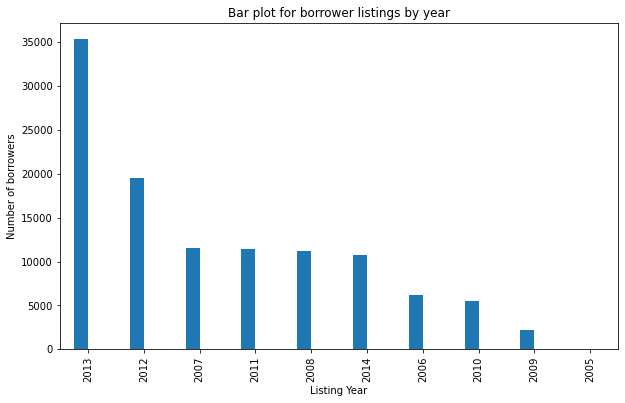

```python
# plot bar graph for months count

simple_bar_plot(listing_year_count, "Listing Year",
                "Number of borrowers",
                "Bar plot for borrower listings by year");
```

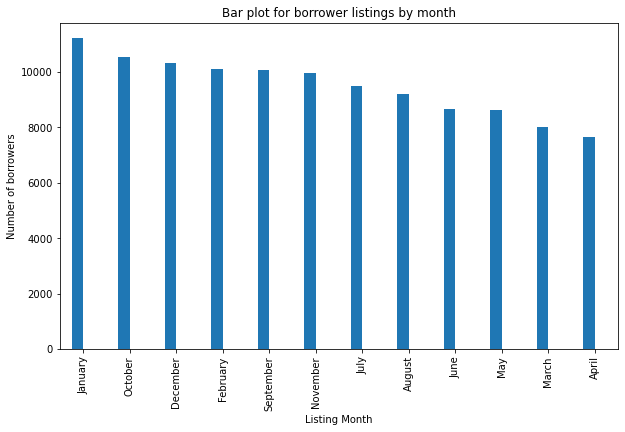

```python
# plot bar graph for months count
simple_bar_plot(listing_month_count, "Listing Month",
                "Number of borrowers",
                "Bar plot for borrower listings by month");
```

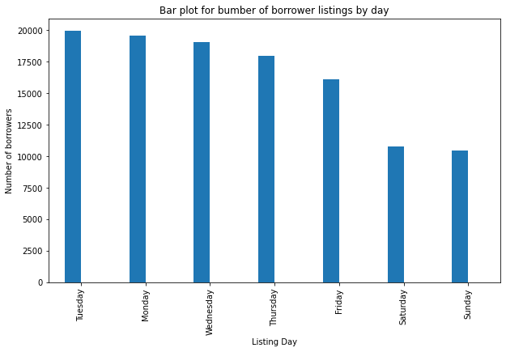

```python
# plot bar graph for days count
simple_bar_plot(listing_day_count, "Listing Day",
                "Number of borrowers",
                "Bar plot for bumber of borrower listings by day");
```

We can see from the above that our dataset entries range from **November 9 2005** till **March 10 2014**, representing over 8 years of loan data collection. **2013** had the highest amount of borrowing while **2005** had the lowest. **January** appears to be the month when people borrow the most, followed by **October**, then **December**. The month with the least amount of borrowing is **April**. Similarly, people borrow the most on **Tuesday** and the least on **Sunday**.

While the *ListingCreationDate* univariate exploration does give us some insight into our dataset, a better way to explore it will be using a time-series plot alongside another variable of interest. This will be explored later in the bivariate exploration section.

#### Variable 2 - Term

**Description:** The length of the loan expressed in months.

**Question:** What is the average term of the listed loans? How are the terms distributed?

```python
prosper_dataset["Term"].describe()
```

```
count    113937.000000
mean         40.830248
std          10.436212
min          12.000000
25%          36.000000
50%          36.000000
75%          36.000000
max          60.000000
Name: Term, dtype: float64
```

```python
unique_vals = prosper_dataset["Term"].unique()

unique_vals
```

```
array([36, 60, 12], dtype=int64)
```

```python
#  Get the count of each unique value in the Term column

unique_counts = prosper_dataset["Term"].value_counts()

unique_counts
```

```
36    87778
60    24545
12     1614
Name: Term, dtype: int64
```

Given the few unique values of the Term feature, a pie or chart will be a good way to explore this variable. Let us use both visualizations for this variable

```python
# Define a function for plotting bar charts using seaborn.

def bar_chart_plotter(df, x, title):
    """
    This function will be used to plot bar graphs using seaborn's countplot.
    The parameters are the dataframe (df), Series to plot(x),
    title of plot (title), xlabel (xlabel), and ylabel (ylabel)
    """
    sns.color_palette()
    base_color = sns.color_palette()[0]
    sns.set_theme(style="darkgrid")
    plt.title(title)
    return sns.countplot(data=df, x=x, color=base_color);
```

```python
# Define a function for plotting pie charts using pyplot.

def pie_plotter(x, labels, title, textprops, autopct, explode):
    """
    x (list or series): The cound of categories to be plotted
    labels (list or series): The category labels to be plotted
    title (string): title of the pie plot
    textprops (dictionary): text customizations
    autopct (string): formating for the text
    explode (list): list representing the pie offset. Should be the same length as the number of categories
    """

    plt.title(title)
    return plt.pie(x=x, labels=labels, textprops=textprops, autopct=autopct, explode=explode)
    plt.legend()
```

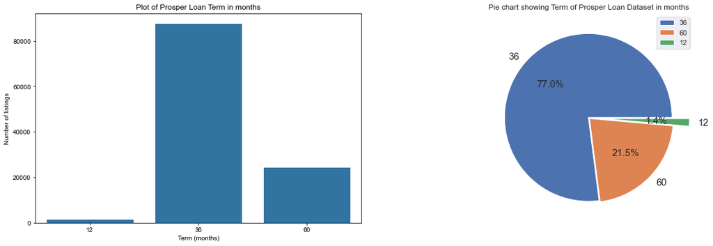

```python
# Plot a bar graph and pie chart of the loan term for the dataset in one plot
plt.figure(figsize = [20, 6])

plt.subplot(1, 2, 1)
bar_chart_plotter(prosper_dataset,
                  prosper_dataset["Term"],
                  "Plot of Prosper Loan Term in months")
plt.xlabel("Term (months)")
plt.ylabel("Number of listings")

plt.subplot(1, 2, 2)
pie_plotter(unique_counts,
            unique_vals,
            "Pie chart showing Term of Prosper Loan Dataset in months",
            {"fontsize":15},
            "%0.1f%%",
            [0.01,0.01,0.2])
plt.legend();
```

#### Variable 3 - LoanStatus

**Description:** The current status of the loan: Cancelled, Chargedoff, Completed, Current, Defaulted, FinalPaymentInProgress, PastDue. The PastDue status will be accomanied by a delinquency bucket.

**Question:** What is the distribution of the loan status for our dataset? Are more people defaulting than are currently paying off their loans?

```python
# get an idea of the values in out LoanStatus categories
print(prosper_dataset["LoanStatus"].nunique())

prosper_dataset["LoanStatus"].unique()
```

```
12
```

```
array(['Completed', 'Current', 'Past Due (1-15 days)', 'Defaulted',
       'Chargedoff', 'Past Due (16-30 days)', 'Cancelled',
       'Past Due (61-90 days)', 'Past Due (31-60 days)',
       'Past Due (91-120 days)', 'FinalPaymentInProgress',
       'Past Due (>120 days)'], dtype=object)
```

There are 12 unique values for the loan status in this dataset, and this can be easily represented using a bar chart. We will create another function that allows us visualize using pyplot

```python
def plt_bar_plotter(x, y, xlabel, title, rotation):
    """
    This function plots a bar chart using pyplot and takes the following parameters::
    x (list or series): category to be plotted on the x-axis
    y (list or series): height of the categories plotted on the x-axis
    xlabel (string): label for the x-axis
    title (string): title of the plot
    rotation (int): xticks the rotation on the x-axis
    """

    # add text to bar chart using for loop
    for i, g in enumerate(y):
        plt.text(i, g, f"{g}", ha="center", fontsize=16, fontweight="bold")

    # add labels to plot
    plt.xlabel(xlabel) # add x-label
    plt.xticks(rotation=rotation) # rotate the x-ticks
    plt.yticks([]) # remove y-ticks
    sns.despine(left=True) # remove left spine
    plt.title(title) # add title to plot
    return plt.bar(x, y, edgecolor="black", color="xkcd:light gray blue");
```

[figure not shown]

```python
fig, ax = plt.subplots(figsize=(15, 5)) # create plot canvas
# save the categories and their counts into variables for plotting
loan_status = list(prosper_dataset["LoanStatus"].unique())
loan_status_counts = prosper_dataset["LoanStatus"].value_counts(sort=True).to_list()

# plot bar chart of loan statuses using pyplot
plt_bar_plotter(loan_status, # loan status categories
                loan_status_counts, # count of categories
                "Loan Status", # x label
                "Current Status of Loans", # title
                90); # xticks rotation
```

#### Variable 4 - BorrowerAPR

**Description:** The Borrower's Annual Percentage Rate (APR) for the loan.

**Question:** At what rates are borrowers getting their loans? What is the distribution of the APR model?

```python
prosper_dataset["BorrowerAPR"].describe()
```

```
count    113912.000000
mean          0.218828
std           0.080364
min           0.006530
25%           0.156290
50%           0.209760
75%           0.283810
max           0.512290
Name: BorrowerAPR, dtype: float64
```

Given the nature of the APR, a histogram will be a good way to see the distribution of the variable. We will first define a function which will allow us plot histograms automatically from this point on.

```python
# Function that plots a histogran
def hist_plotter(df, x, bins, xlabel, ylabel, title):
    """
    This function plots a histogram using the following parameters:
    df (DataFrame): The dataframe object
    x (series): The series to be plotted on the histogram
    bin (list): the number of bins to plot
    xlabel (string): label on the x-axis
    ylabel (string): label on the y-axis
    title (string): title of the plot
    """
    plt.xlabel(xlabel)
    plt.ylabel(ylabel)
    plt.title(title)
    return plt.hist(data=df, x=x, bins=bins)
```

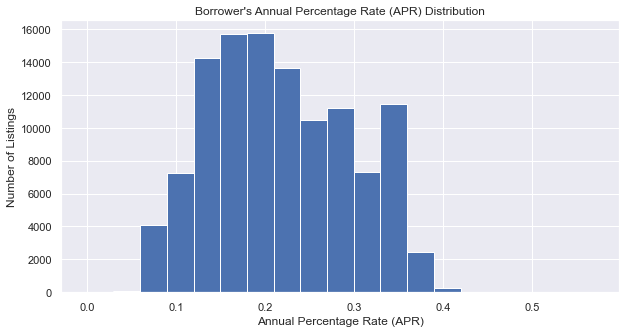

```python
fig, ax = plt.subplots(figsize=(10, 5)) # create plot canvas
# customize bins
bins = np.arange(0.00, 0.5+0.1, 0.03)

# plot histogram using borrower's APR
hist_plotter(prosper_dataset,
             "BorrowerAPR",
             bins,
             "Annual Percentage Rate (APR)","Number of Listings",
             "Borrower's Annual Percentage Rate (APR) Distribution");
```

#### Variable 5 - BorrowerState

**Description:** The two letter abbreviation of the state of the address of the borrower at the time the Listing was created.

**Question:** What state has the highest number of borrowers?

```python
# Get the number of states with borrowers
print(prosper_dataset["BorrowerState"].nunique())

# Print out the list of all the states with borrowers listed
prosper_dataset["BorrowerState"].unique()
```

```
51
```

```
array(['CO', 'GA', 'MN', 'NM', 'KS', 'CA', 'IL', 'MD', nan, 'AL', 'AZ',
       'VA', 'FL', 'PA', 'OR', 'MI', 'NY', 'LA', 'WI', 'OH', 'NC', 'WA',
       'NV', 'NJ', 'TX', 'AR', 'SC', 'DE', 'MO', 'NE', 'UT', 'DC', 'MA',
       'CT', 'IN', 'KY', 'OK', 'MS', 'WV', 'RI', 'TN', 'ID', 'MT', 'HI',
       'NH', 'VT', 'WY', 'ME', 'AK', 'IA', 'SD', 'ND'], dtype=object)
```

Given the high number of states, it would be difficult to plot everything at once, so we will plot the top 10 and bottom 10 states in terms of the number of borrowers listed. A bar chart will be a great way to visualize this.

```python
# Get the states with the highest number of borrowers.

print(prosper_dataset["BorrowerState"].value_counts().head(10))

prosper_dataset["BorrowerState"].value_counts().tail(10)
```

```
CA    14717
TX     6842
NY     6729
FL     6720
IL     5921
GA     5008
OH     4197
MI     3593
VA     3278
NJ     3097
Name: BorrowerState, dtype: int64
```

```
DC    382
MT    330
DE    300
VT    207
AK    200
SD    189
IA    186
WY    150
ME    101
ND     52
Name: BorrowerState, dtype: int64
```

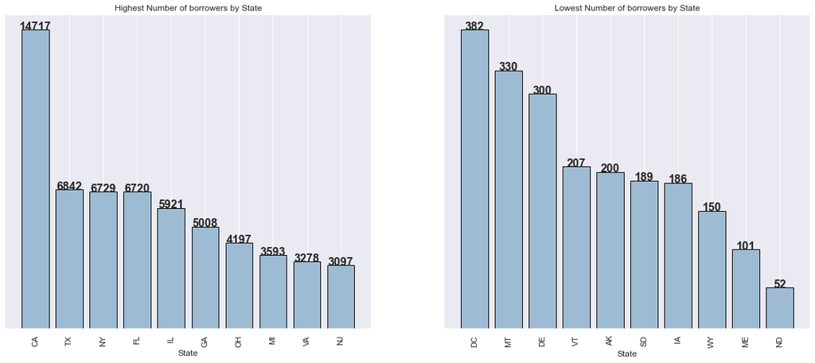

```python
# save variables for plotting
# highest number of borrowers
state_list_top = prosper_dataset["BorrowerState"].value_counts(sort=True).head(10).index
state_counts_top = prosper_dataset["BorrowerState"].value_counts(sort=True).head(10).to_list()
# least number of borrowers
state_list_bottom = prosper_dataset["BorrowerState"].value_counts(sort=True).tail(10).index
state_counts_bottom = prosper_dataset["BorrowerState"].value_counts(sort=True).tail(10).to_list()

fig, ax = plt.subplots(figsize=(20, 8)) # create plot canvas

plt.subplot(1, 2, 1)
# plot bar chart of borrower states
plt_bar_plotter(state_list_top, # borrower state
                state_counts_top, # count of borrowers
                "State", # x-label
                "Highest Number of borrowers by State", # title
                90); # xticks rotation

plt.subplot(1, 2, 2)
# plot bar chart of borrower states
plt_bar_plotter(state_list_bottom, # borrower state
                state_counts_bottom, # count of borrowers
                "State", # x-label
                "Lowest Number of borrowers by State", # title
                90); # xticks rotation
```

It is not surprising to see that California (CA) has the highest number of listed borrowers, given its status as the most populous state and one of the most important commercial hubs in the country. The number of borrowers listed are more than double the next state, Texas (TX) which had 6842 borrowers.

In contrast, North Dakota (ND) and Maine (ME) have the lowest number of listed borrowers, with 52 and 101 borrowers respectively.

This is a very important variable that would be interesting to explore using bivariate or multivariate analysis, if possible.

#### Variable 6 - EmploymentStatus

**Description:** The employment status of the borrower at the time they posted the listing.

**Question:** What is the employment status of borrowers like as at the time the listing was posetd?

```python
employ_status = prosper_dataset.groupby("EmploymentStatus").size().reset_index(name="counts")

employ_status
```

|  | EmploymentStatus | counts |
| --- | --- | --- |
| 0 | Employed | 67322 |
| 1 | Full-time | 26355 |
| 2 | Not available | 5347 |
| 3 | Not employed | 835 |
| 4 | Other | 3806 |
| 5 | Part-time | 1088 |
| 6 | Retired | 795 |
| 7 | Self-employed | 6134 |

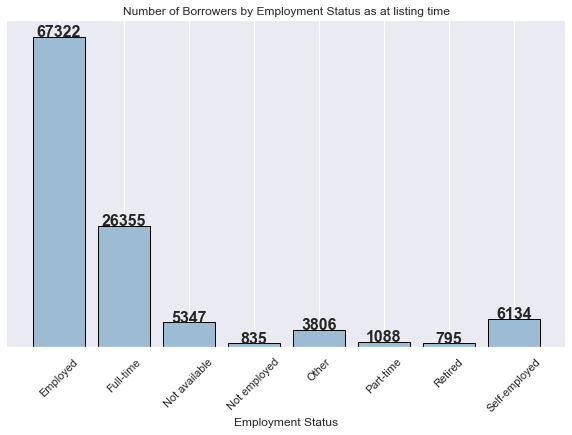

```python
fig, ax = plt.subplots(figsize=(10, 6)) # create plot canvas

plt_bar_plotter(employ_status["EmploymentStatus"], # employment status
                employ_status["counts"], # count of status
                "Employment Status", # x-label
                "Number of Borrowers by Employment Status as at listing time", # title
                45); # xticks rotation
```

#### Variable 7 - IsBorrowerHomeowner

**Description:** A Borrower will be classified as a homowner if they have a mortgage on their credit profile or provide documentation confirming they are a homeowner.

**Question:** What percentage of our borrowers are homeowners?

```python
homeowner_status = prosper_dataset["IsBorrowerHomeowner"].unique()

homeowner_status
```

```
array([ True, False])
```

```python
homeowner_counts = prosper_dataset["IsBorrowerHomeowner"].value_counts().to_list()

homeowner_counts
```

```
[57478, 56459]
```

Given the nature of the Home owner variable, a pie chart will be the best option to visualize it.

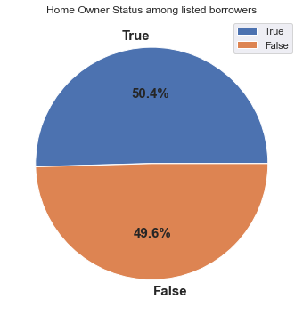

```python
# Plot pie chart of homeonwer status

fig, ax = plt.subplots(figsize=(10, 6)) # create plot canvas

pie_plotter(homeowner_counts, # count of homeowners
            homeowner_status, # labels
            "Home Owner Status among listed borrowers", # title of plot
            {"fontsize":15, "fontweight":"bold"}, # text customization
            "%0.1f%%", # Value formatting
            [0.001,0.001]) # explode pie slices
plt.legend();
```

The home owner status of borrowers is roughly split in half between True and False, with 50.4% of borrowers being homeowners and 49.6% being non-homeowners

#### Variable 8 - IncomeRange

**Description:** The income range of the borrower at the time the listing was created.

**Question**: What is the distribution of the income range for listed borrowers?

```python
income_range_counts = prosper_dataset["IncomeRange"].value_counts().to_frame()

income_range_counts["percentage"] = income_range_counts["IncomeRange"] / len(prosper_dataset) * 100

income_range_counts
```

|  | IncomeRange | percentage |
| --- | --- | --- |
| $25,000-49,999 | 32192 | 28.254211 |
| $50,000-74,999 | 31050 | 27.251902 |
| $100,000+ | 17337 | 15.216304 |
| $75,000-99,999 | 16916 | 14.846801 |
| Not displayed | 7741 | 6.794106 |
| $1-24,999 | 7274 | 6.384230 |
| Not employed | 806 | 0.707408 |
| $0 | 621 | 0.545038 |

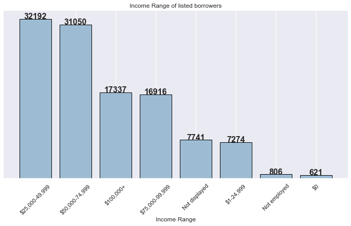

```python
# plot Income range distribution on bar chart

fig, ax = plt.subplots(figsize=(12, 6)) # create plot canvas

plt_bar_plotter(income_range_counts.index, # values to plot
                income_range_counts["IncomeRange"].to_list(), # count of values
                "Income Range", # x-label
                "Income Range of listed borrowers", # title
                45); # xticks rotation
```

```python
# Generate random dataset and seed for reproducibility.
np.random.seed(5000)
sample = np.random.choice(prosper_dataset.shape[0], 2000, replace=False)
prosper_data_rand = prosper_dataset.loc[sample]
```

#### Variable 9 - StatedMonthlyIncome

**Description:** The monthly income the borrower stated at the time the listing was created.

**Question:** How is monthly income distributed among borrowers?

```python
# set display format for floats
pd.options.display.float_format = '{:.4f}'.format
```

```python
# Get summary statistics for income distribution
prosper_dataset["StatedMonthlyIncome"].describe()
```

```
count    113937.0000
mean       5608.0256
std        7478.4973
min           0.0000
25%        3200.3333
50%        4666.6667
75%        6825.0000
max     1750002.9167
Name: StatedMonthlyIncome, dtype: float64
```

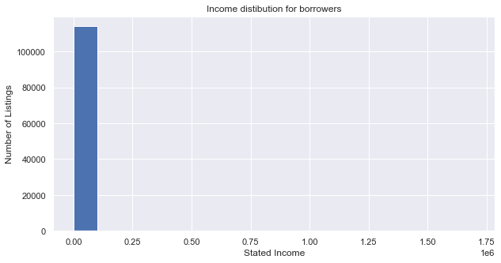

```python
# Plot histogram from the stated monthly income column to see the distribution
fig, ax = plt.subplots(figsize=(10, 5)) # create plot canvas
# customize bins
bins = np.arange(0.00, 1750000, 100000)

# plot histogram of stated income
hist_plotter(prosper_dataset,
             "StatedMonthlyIncome",
             bins,
             "Stated Income",
             "Number of Listings",
             "Income distibution for borrowers");
```

The summary statistics and histogram above show that the income distribution is highly skewed and there will be the need to transform to get the actual distribution. We will also need to perform some wrangling at this stage to only include datasets with income above zero for the purpose of our transformation.

```python
# subset data to only those with income above zero.
# We will continue working with this new dataset henceforth.
prosper_dataset = prosper_dataset[prosper_dataset["StatedMonthlyIncome"] > 0]

print(prosper_dataset["StatedMonthlyIncome"].info())

prosper_dataset["StatedMonthlyIncome"].describe()
```

```
<class 'pandas.core.series.Series'>
Int64Index: 112543 entries, 0 to 113936
Series name: StatedMonthlyIncome
Non-Null Count   Dtype
--------------   -----
112543 non-null  float64
dtypes: float64(1)
memory usage: 1.7 MB
None
```

```
count    112543.0000
mean       5677.4887
std        7498.4193
min           0.0833
25%        3293.3333
50%        4703.0000
75%        6833.3333
max     1750002.9167
Name: StatedMonthlyIncome, dtype: float64
```

```python
# Get idea of bins to plot from log transform
np.log(prosper_dataset["StatedMonthlyIncome"].describe())
```

```
count   11.6311
mean     8.6443
std      8.9224
min     -2.4849
25%      8.0997
50%      8.4560
75%      8.8296
max     14.3751
Name: StatedMonthlyIncome, dtype: float64
```

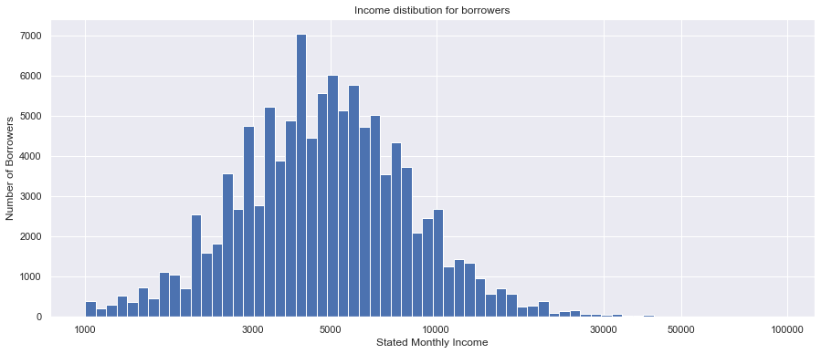

```python
# Plot histogram with the log transform
fig, ax = plt.subplots(figsize=(15, 6)) # create plot canvas
# customize bins
bins = 10 ** np.arange(3, 5, 0.03)

# Generate the x-ticks you want to apply
ticks = [1000, 3000, 5000, 10000, 30000, 50000, 100000]

# Convert ticks into string values, to be displayed along the x-axis
labels = ['{}'.format(v) for v in ticks]

# plot histogram of stated income
hist_plotter(prosper_dataset,
             "StatedMonthlyIncome",
             bins,
             "Stated Monthly Income",
             "Number of Borrowers",
             "Income distibution for borrowers")
# Apply log scale
plt.xscale("log")
# Apply x-ticks
plt.xticks(ticks, labels);
```

With the log scale, we can see that the stated monthly income now closely resembles a normal distribution, with the highest number of borrowers earning between around 2000 and 10000 dollars. The monthly income variable is one other interesting variable we will explore in a bavariate or multivariate visualization.

#### Variable 10 - ProsperScore

**Description:** A custom risk score built using historical Prosper data. The score ranges from 1-10, with 10 being the best, or lowest risk score. Applicable for loans originated after July 2009.

**Question:** What does the risk score look like for the average borrower?

```python
# Get summary statistics for the ProsperScore variable
prosper_dataset["ProsperScore"].describe()
```

```
count   84160.0000
mean        5.9558
std         2.3788
min         1.0000
25%         4.0000
50%         6.0000
75%         8.0000
max        11.0000
Name: ProsperScore, dtype: float64
```

```python
# Get the value count for each rating
prosper_dataset["ProsperScore"].value_counts()
```

```
4.0000     12477
6.0000     12155
8.0000     11980
7.0000     10506
5.0000      9698
3.0000      7563
9.0000      6883
2.0000      5710
10.0000     4747
11.0000     1456
1.0000       985
Name: ProsperScore, dtype: int64
```

The value count show that there are listings with scores higher than 10. We will assume this is an error since the documentation provides for only ratings between 1 and 10. We will subset our dataset to those with ratings that only fall between this.

```python
# subset dataframe to only listings with ratings between 1 and 10.
prosper_ratings_normal = prosper_dataset[prosper_dataset["ProsperScore"] < 11]

# Group the new subset by score
prosper_ratings_normal_group = prosper_ratings_normal.groupby("ProsperScore").size().reset_index(name="counts")

# describe the subset prosper score
print(prosper_ratings_normal["ProsperScore"].describe())

# view the new dataframe summary
prosper_ratings_normal_group
```

```
count   82704.0000
mean        5.8670
std         2.3027
min         1.0000
25%         4.0000
50%         6.0000
75%         8.0000
max        10.0000
Name: ProsperScore, dtype: float64
```

|  | ProsperScore | counts |
| --- | --- | --- |
| 0 | 1.0000 | 985 |
| 1 | 2.0000 | 5710 |
| 2 | 3.0000 | 7563 |
| 3 | 4.0000 | 12477 |
| 4 | 5.0000 | 9698 |
| 5 | 6.0000 | 12155 |
| 6 | 7.0000 | 10506 |
| 7 | 8.0000 | 11980 |
| 8 | 9.0000 | 6883 |
| 9 | 10.0000 | 4747 |

We will visualize our prosper scores using seaborn's countplot.

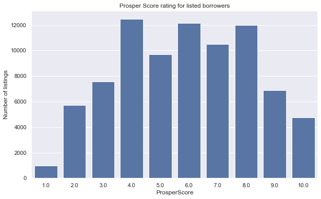

```python
# Plot bar graph
fig, ax = plt.subplots(figsize=(10, 6)) # create plot canvas

bar_chart_plotter(prosper_ratings_normal,
                  prosper_ratings_normal["ProsperScore"],
                  "Prosper Score rating for listed borrowers")
plt.xlabel("ProsperScore")
plt.ylabel("Number of listings");
```

It is interesting to see that most of the borrowers listed fell into the score category "4", even though the average score was "6", and 75% of borrowers had scores between "1" and "8". This goes to show that averages can sometimes not truly represent our data.

#### Variable 11 - ListingCategory

**Description:** The category of the listing that the borrower selected when posting their listing: 0 - Not Available, 1 - Debt Consolidation, 2 - Home Improvement, 3 - Business, 4 - Personal Loan, 5 - Student Use, 6 - Auto, 7- Other, 8 - Baby&Adoption, 9 - Boat, 10 - Cosmetic Procedure, 11 - Engagement Ring, 12 - Green Loans, 13 - Household Expenses, 14 - Large Purchases, 15 - Medical/Dental, 16 - Motorcycle, 17 - RV, 18 - Taxes, 19 - Vacation, 20 - Wedding Loans

**Question**: What do people borrow money for the most?

```python
# Print out the list of categories
print(prosper_dataset["ListingCategory (numeric)"].nunique())

cats = list(prosper_dataset["ListingCategory (numeric)"].unique())

cats
```

```
21
```

```
[0, 2, 16, 1, 7, 13, 6, 15, 20, 19, 18, 3, 8, 4, 11, 14, 5, 9, 17, 10, 12]
```

```python
# Create dataframe with full listing category

listing_cats = prosper_dataset.groupby("ListingCategory (numeric)").size().reset_index(name="counts")

listing_cats["Listing Category"] = ["Not Available", "Debt Consolidation", "Home Improvement",
                                    "Business", "Personal Loan", "Student Use", "Auto", "Other",
                                    "Baby&Adoption", "Boat", "Cosmetic Procedure", "Engagement Ring",
                                    "Green Loans", "Household Expenses", "Large Purchases",
                                    "Medical/Dental", "Motorcycle", "RV", "Taxes", "Vacation", "Wedding Loans"]

listing_cats
```

|  | ListingCategory (numeric) | counts | Listing Category |
| --- | --- | --- | --- |
| 0 | 0 | 16727 | Not Available |
| 1 | 1 | 57950 | Debt Consolidation |
| 2 | 2 | 7386 | Home Improvement |
| 3 | 3 | 6940 | Business |
| 4 | 4 | 2274 | Personal Loan |
| 5 | 5 | 689 | Student Use |
| 6 | 6 | 2544 | Auto |
| 7 | 7 | 10311 | Other |
| 8 | 8 | 198 | Baby&Adoption |
| 9 | 9 | 84 | Boat |
| 10 | 10 | 90 | Cosmetic Procedure |
| 11 | 11 | 213 | Engagement Ring |
| 12 | 12 | 57 | Green Loans |
| 13 | 13 | 1940 | Household Expenses |
| 14 | 14 | 870 | Large Purchases |
| 15 | 15 | 1505 | Medical/Dental |
| 16 | 16 | 304 | Motorcycle |
| 17 | 17 | 52 | RV |
| 18 | 18 | 881 | Taxes |
| 19 | 19 | 760 | Vacation |
| 20 | 20 | 768 | Wedding Loans |

As this is a categorical variable, a bar chart will be a great way to see what category people tended to borrow money for.

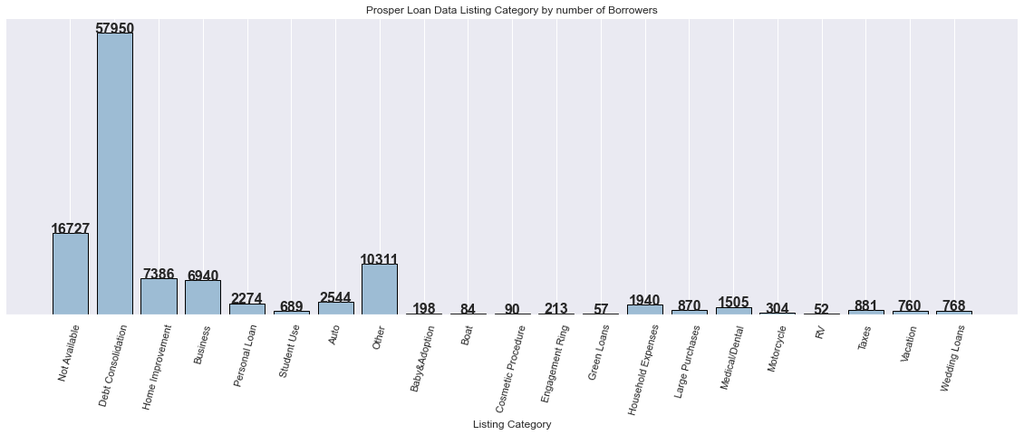

```python
fig, ax = plt.subplots(figsize=(20, 6)) # create plot canvas
plt_bar_plotter(listing_cats["Listing Category"],
                listing_cats["counts"],
                "Listing Category",
                "Prosper Loan Data Listing Category by number of Borrowers",
                75);
```

From the chart, more than half (51.5%) of the borrowers took their loans for the consolidation of other debts while a little over 10% did not specify the reason for taking on the debt.

#### Variable 12 - LoanOriginalAmount

**Description:** The origination amount of the loan.

What was the average amount of money borrowed? What is the range?

```python
prosper_dataset["LoanOriginalAmount"].describe()
```

```
count   112543.0000
mean      8364.7371
std       6249.2212
min       1000.0000
25%       4000.0000
50%       6500.0000
75%      12000.0000
max      35000.0000
Name: LoanOriginalAmount, dtype: float64
```

For visualizing the distribution of the loan original amount, let us use box plots. We will create a function in case we need to reuse the plot

```python
# function definition for plotting a box plot
def plot_a_box(data, series, color, title):
    """
    This function will plot a box and whiskers plot using the following arguments:
    data (DataFrame): the DataFrame of interest
    series (Series or list): the series or list to be visualized
    color (string): color of the box
    title (string): title to be used for the plot.
    """
    fig, ax = plt.subplots(figsize=(8, 5))
    box = data[series].plot(ax=ax, kind="box", vert=False, color=color, title=title)
    return box
```

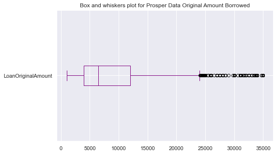

```python
# Plot box plot for loan amount data
plot_a_box(prosper_dataset,
           "LoanOriginalAmount",
           "#800080",
           "Box and whiskers plot for Prosper Data Original Amount Borrowed");
```

The box plot above shows that the data available for loan amount borrowed is positively skewed, with 25% of borrowers borrowing less than 4000 dollars, and 75% borrowing less than 12000 dollars. The median amount borrowed was 6500 dollars. Borrowers with 24000 dollars and above are responsible for the skew as they are considered outliers.

#### Variable 13 - BorrowerRate

**Description:** The Borrower's interest rate for this loan.

**Question:** What is the average interest rate for borrowing?

```python
prosper_dataset["BorrowerRate"].describe()
```

```
count   112543.0000
mean         0.1924
std          0.0746
min          0.0000
25%          0.1334
50%          0.1830
75%          0.2500
max          0.4975
Name: BorrowerRate, dtype: float64
```

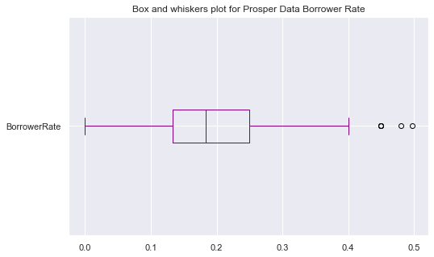

```python
# Plot box plot for loan amount data
plot_a_box(prosper_dataset,
           "BorrowerRate",
           "#800080",
           "Box and whiskers plot for Prosper Data Borrower Rate");
```

### Of the features you investigated, were there any unusual distributions? Did you perform any operations on the data to tidy, adjust, or change the form of the data? If so, why did you do this?

> A few transformations and cleaning had to be done in the univariate analysis process.
> - The loan listing date had to be converted to the datetime type for any analysis to be performed.
> - The monthly income distribution did not appear normally at first, and had to be transforemed using a log scale for the distribution to appear normally.
> - Our dataset was subset to include only those with stated income higher than zero.

## Bivariate Exploration

> We will now move on to the bivariate exploration of the loan dataset, so we can get some more useful insights into our data

#### Investigation 1: ProsperScore vs LoanStatus

**Question**: Does a borrower's rating affect how they end up with their loans? What prosper score do borrowers who default have on average? Let us explore what this relationship will unfold.

From our earlier univariate analysis, we had created a subset that only includes datasets with ratings between 1 and 10 (`prosper_ratings_normal`), and we will continue our work here with that dataset.

```python
prosper_ratings_normal["LoanStatus"].unique()
```

```
array(['Current', 'Past Due (1-15 days)', 'Defaulted', 'Completed',
       'Chargedoff', 'Past Due (16-30 days)', 'Past Due (61-90 days)',
       'Past Due (31-60 days)', 'Past Due (91-120 days)',
       'FinalPaymentInProgress', 'Past Due (>120 days)'], dtype=object)
```

```python
# Define a function to plot a violin plot and 2D box plot
def violin_chart(data, x, y, xlabel, ylabel, title):
    """
    Function plots a violin plot using the parameters:
    data (DataFrame): DataFrame containing the data to be plotted.
    x (series): categorical series to plot on the x axis
    y (series): quantitavie series to be plotted on the y axis
    xlabel (str): x label for the plot
    ylabel (str): y label for the plot
    title (title): title of the plot
    """
    fig, ax = plt.subplots(figsize=(18, 6))
    base_color = sns.color_palette()[0]
    violin = sns.violinplot(data=data, x=x, y=y, ax=ax, color=base_color)
    plt.xticks(rotation=90)
    plt.xlabel(xlabel)
    plt.ylabel(ylabel)
    plt.title(title);
    return violin

def box_chart_2D(data, x, y, xlabel, ylabel, title):
    """
    Function plots a 2D box plot using the parameters:
    data (DataFrame): DataFrame containing the data to be plotted.
    x (series): categorical series to plot on the x axis
    y (series): quantitavie series to be plotted on the y axis
    xlabel (str): x label for the plot
    ylabel (str): y label for the plot
    title (title): title of the plot
    """
    fig, ax = plt.subplots(figsize=(18, 6))
    base_color = sns.color_palette()[0]
    box_chart = sns.boxplot(data=data, x=x, y=y, ax=ax, color=base_color)
    plt.xticks(rotation=90)
    plt.xlabel(xlabel)
    plt.ylabel(ylabel)
    plt.title(title);
    return box_chart
```

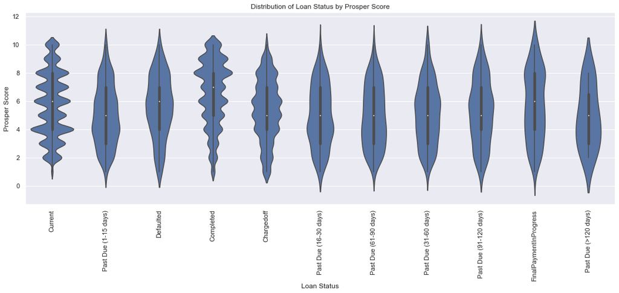

```python
# Plot violin plot of Prosper score and Loan Status

violin_chart(prosper_ratings_normal, "LoanStatus", "ProsperScore", "Loan Status", "Prosper Score", "Distribution of Loan Status by Prosper Score");
```

The above chart can also be visualized using a 2D box plot to get a clearer picture of the distribution.

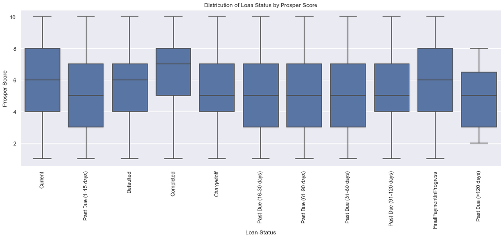

```python
# Plot box plot of Prosper score and Loan Status

box_chart_2D(prosper_ratings_normal, "LoanStatus", "ProsperScore", "Loan Status", "Prosper Score", "Distribution of Loan Status by Prosper Score");
```

It is obvious from the charts above that borrowers with the prosper risk score of **(7)** were the most likely to complete their loans, while those with a prosper risk score of **6** or less were likely to default.

#### Investigation 2: LoanOriginalAmount vs StatedMonthlyIncome

**Question:** How does a borrower's monthly income affect how they borrow? To visualize this relationship, we will employ the use of a scatter plot and the correlation.

```python
# Define a function to plot scatter plots.

def plot_scatter(data, x, y, xlabel, ylabel, a_x, a_y, color, title):
    """
    A bivariate scatter plotting function. Parameters are:
    data (DataFrame): The DataFrame that contains observations to be plotted
    x (str): series or column to plot on x-axis
    y (str): series or column to plot on y-axis
    xlabel (str): x axis label
    ylabel (str): y axis label
    a_x (int): length of x axis
    a_y (int): length of y axis
    color (str or hex): color of plot
    title (str): plot title
    """
    fig, ax = plt.subplots(figsize=(12, 6))
    ax.plot([0, a_x], [0, a_y], linestyle="--", color="#800080")
    scatter = data.plot(x, y, kind="scatter", color=color, title=title, ax=ax, alpha=0.9)
    plt.xlabel(xlabel)
    plt.ylabel(ylabel);
    return scatter
```

```python
# get correlation coefficient of borrower monthly income and loan amount
prosper_dataset["StatedMonthlyIncome"].corr(prosper_dataset["LoanOriginalAmount"])
```

```
0.19974080694069674
```

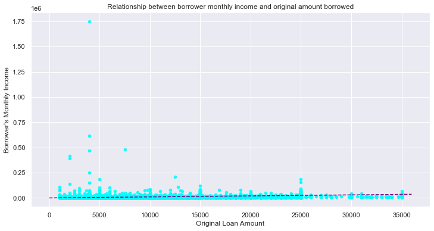

```python
# plot scatter plot of borrower monthly income and original loan amount.
plot_scatter(prosper_dataset, "LoanOriginalAmount", "StatedMonthlyIncome",
             "Original Loan Amount", "Borrower's Monthly Income",
             36000, 36000, "#00FFFF",
             "Relationship between borrower monthly income and original amount borrowed");
```

Based on the entire dataset, there is a very weak relationship between a borrower's income and how much they borrowed as loan, however, the data shows that mostly only low income earners (typically earning less than $50000) borrowed. In order to dig in more into this relationship, we will use the earlier generated random subset of our dataset and plot another scatter diagram.

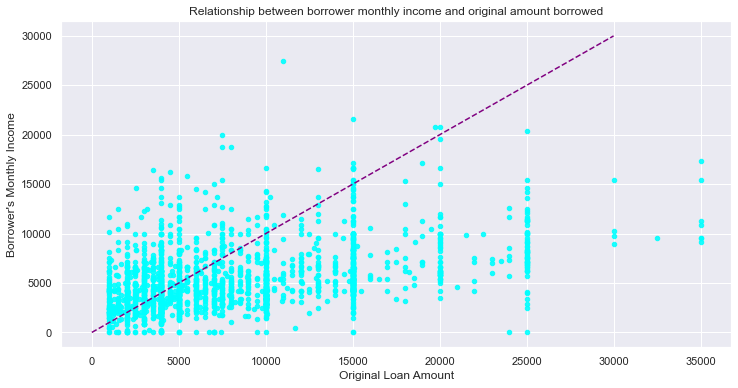

```python
# plot scatter plot of borrower monthly income and original loan amount.
plot_scatter(prosper_data_rand, "LoanOriginalAmount", "StatedMonthlyIncome",
             "Original Loan Amount", "Borrower's Monthly Income",
             30000, 30000, "#00FFFF",
             "Relationship between borrower monthly income and original amount borrowed");
```

```python
# get correlation coefficient of borrower monthly income and loan amount
prosper_data_rand["StatedMonthlyIncome"].corr(prosper_data_rand["LoanOriginalAmount"])
```

```
0.4189600151580486
```

We can see from above that there is a much stronger positive relationship between the income and amount borrowed. Generally, the higher a borrower's income, the more they tend to borrow.

#### Investigation 3: LoanOriginalAmount vs BorrowerRate/BorrowerAPR

**Question:** Is there any dependence of the APR/Interest Rate on the amount borrowed? Let us calculating the coefficient of correlation between the two variables.

```python
prosper_dataset["LoanOriginalAmount"].corr(prosper_dataset["BorrowerAPR"])
```

```
-0.3241576725500873
```

```python
prosper_dataset["LoanOriginalAmount"].corr(prosper_dataset["BorrowerRate"])
```

```
-0.33062595925551863
```

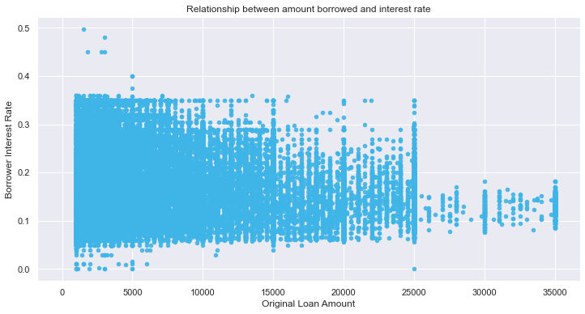

```python
# plot scatter plot of borrower original loan amount and Annual Percentage rate
plot_scatter(prosper_dataset, "LoanOriginalAmount", "BorrowerRate",
             "Original Loan Amount", "Borrower Interest Rate",
             0, 0, "#3EB4E7",
             "Relationship between amount borrowed and interest rate");
```

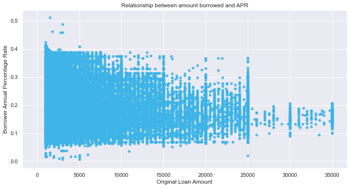

```python
# plot scatter plot of borrower original loan amount and Annual Percentage rate
plot_scatter(prosper_dataset, "LoanOriginalAmount", "BorrowerAPR",
             "Original Loan Amount", "Borrower Annual Percentage Rate",
             0, 0, "#3EB4E7",
             "Relationship between amount borrowed and APR");
```

The plot above shows that generally, the higher the anount borrowed, the lower the APR/Interest Rate of the loan, This is also backed up by the coefficient of correlation which is negative in value and tending toward the midpoint.

#### Investigation 4: LoanStatus vs BorrowerAPR/BorrowerRate

**Question:** What relationship exists between a loan's APR/Rate and how the loan status ends? Do higher APR/Rates mean a lot of defaulting? Let us find out.

```python
# group relationship between LoanStatus and APR
status_apr_rel = prosper_dataset.groupby("LoanStatus")["BorrowerAPR"].mean().to_frame()

status_apr_rel
```

| LoanStatus | BorrowerAPR |
| --- | --- |
| Cancelled | 0.1932 |
| Chargedoff | 0.2575 |
| Completed | 0.2085 |
| Current | 0.2133 |
| Defaulted | 0.2389 |
| FinalPaymentInProgress | 0.2296 |
| Past Due (1-15 days) | 0.2636 |
| Past Due (16-30 days) | 0.2679 |
| Past Due (31-60 days) | 0.2652 |
| Past Due (61-90 days) | 0.2730 |
| Past Due (91-120 days) | 0.2705 |
| Past Due (>120 days) | 0.2791 |

```python
# group relationship between LoanStatus and BorrowerRate
status_rate_rel = prosper_dataset.groupby("LoanStatus")["BorrowerRate"].mean().to_frame()

status_rate_rel
```

| LoanStatus | BorrowerRate |
| --- | --- |
| Cancelled | 0.1711 |
| Chargedoff | 0.2352 |
| Completed | 0.1862 |
| Current | 0.1834 |
| Defaulted | 0.2231 |
| FinalPaymentInProgress | 0.1970 |
| Past Due (1-15 days) | 0.2306 |
| Past Due (16-30 days) | 0.2347 |
| Past Due (31-60 days) | 0.2325 |
| Past Due (61-90 days) | 0.2398 |
| Past Due (91-120 days) | 0.2379 |
| Past Due (>120 days) | 0.2484 |

```python
# Define a function that plots line graphs from groupby dataframe
def line_graph_plot(data, xlabel, ylabel, title, rotation):
    """
    Line graph plotter
    """
    fig, ax = plt.subplots(figsize=(12, 5))
    line = data.plot(kind="line", ax=ax)
    plt.xlabel(xlabel)
    plt.ylabel(ylabel)
    plt.title(title)
    plt.xticks(rotation=rotation)
    return line
```

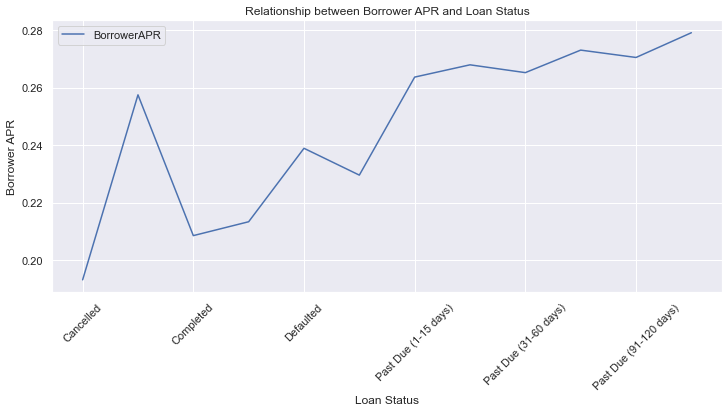

```python
# Plot line graph for BorrowerAPR and LoanStatus
line_graph_plot(status_apr_rel,
                "Loan Status", "Borrower APR",
                "Relationship between Borrower APR and Loan Status",
                45);
```

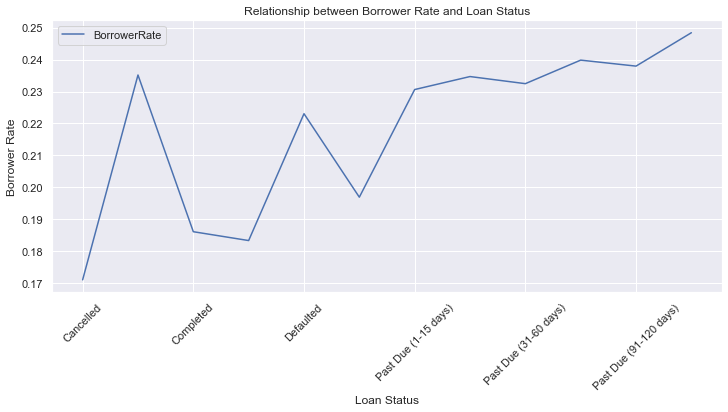

```python
# Plot line graph for BorrowerRate and LoanStatus
line_graph_plot(status_rate_rel,
                "Loan Status", "Borrower Rate",
                "Relationship between Borrower Rate and Loan Status",
                45);
```

The higher a loan's rate/APR, the higher the chances of a defaulting, as seen from the above chart of loan status with APR/borrower rate.

#### Investigation 5: LoanStatus vs LoanOriginalAmount

**Question:** What is the likelyhood of a default based on the amount borrowed?

```python
status_amount_rel = prosper_dataset.groupby("LoanStatus")["LoanOriginalAmount"].mean().to_frame()
```

```python
status_amount_rel
```

| LoanStatus | LoanOriginalAmount |
| --- | --- |
| Cancelled | 1875.0000 |
| Chargedoff | 6377.1221 |
| Completed | 6202.3844 |
| Current | 10383.4047 |
| Defaulted | 6444.4226 |
| FinalPaymentInProgress | 8346.1220 |
| Past Due (1-15 days) | 8473.4176 |
| Past Due (16-30 days) | 8211.3615 |
| Past Due (31-60 days) | 8558.2333 |
| Past Due (61-90 days) | 7758.1569 |
| Past Due (91-120 days) | 8044.7143 |
| Past Due (>120 days) | 8633.3333 |

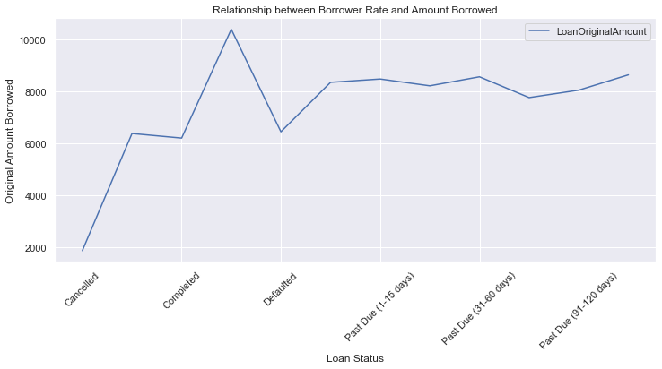

```python
# Plot line graph for Amount Borrowed and LoanStatus
line_graph_plot(status_amount_rel,
                "Loan Status", "Original Amount Borrowed",
                "Relationship between Borrower Rate and Amount Borrowed",
                45);
```

#### Investigation 6: LoanStatus vs Home ownership

**Question:** Is there any significant difference between homeowners and non-homeowners when it comes to loan repayment/status?

```python
status_homeowner_rel = prosper_dataset.groupby(["LoanStatus"])["IsBorrowerHomeowner"].value_counts().to_frame().unstack()

status_homeowner_rel
```

| IsBorrowerHomeowner LoanStatus | IsBorrowerHomeowner False | IsBorrowerHomeowner True |
| --- | --- | --- |
| Cancelled | 3 | 1 |
| Chargedoff | 6444 | 5201 |
| Completed | 19338 | 18059 |
| Current | 25913 | 30404 |
| Defaulted | 2702 | 2236 |
| FinalPaymentInProgress | 95 | 110 |
| Past Due (1-15 days) | 422 | 373 |
| Past Due (16-30 days) | 133 | 127 |
| Past Due (31-60 days) | 178 | 182 |
| Past Due (61-90 days) | 130 | 176 |
| Past Due (91-120 days) | 174 | 127 |
| Past Due (>120 days) | 7 | 8 |

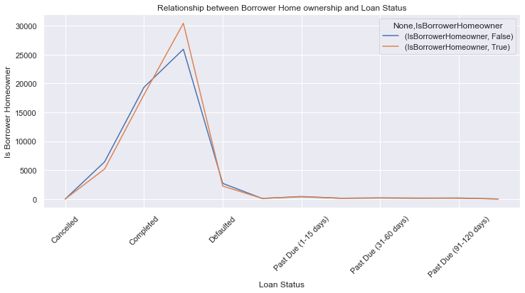

```python
# Plot line graph for Home ownership and LoanStatus
line_graph_plot(status_homeowner_rel,
                "Loan Status", "Is Borrower Homeowner",
                "Relationship between Borrower Home ownership and Loan Status",
                45);
```

There does not appear to be any significant difference between borrowers with homes and those without homes in the payments of the loan statuses.

```python
prosper_dataset.groupby(["LoanStatus"])["IncomeRange"].value_counts().unstack()
```

| IncomeRange LoanStatus | $0 | $1-24,999 | $100,000+ | $25,000-49,999 | $50,000-74,999 | $75,000-99,999 | Not displayed | Not employed |
| --- | --- | --- | --- | --- | --- | --- | --- | --- |
| Cancelled | NaN | NaN | NaN | 1.0000 | NaN | NaN | 3.0000 | NaN |
| Chargedoff | 1.0000 | 1329.0000 | 968.0000 | 4162.0000 | 2633.0000 | 1153.0000 | 1377.0000 | 22.0000 |
| Completed | NaN | 2906.0000 | 4774.0000 | 10891.0000 | 9282.0000 | 4914.0000 | 4579.0000 | 51.0000 |
| Current | NaN | 2536.0000 | 10916.0000 | 15111.0000 | 17615.0000 | 10139.0000 | NaN | NaN |
| Defaulted | NaN | 334.0000 | 322.0000 | 1290.0000 | 874.0000 | 375.0000 | 1736.0000 | 7.0000 |
| FinalPaymentInProgress | NaN | 14.0000 | 52.0000 | 49.0000 | 64.0000 | 26.0000 | NaN | NaN |
| Past Due (1-15 days) | NaN | 52.0000 | 134.0000 | 266.0000 | 212.0000 | 131.0000 | NaN | NaN |
| Past Due (16-30 days) | NaN | 20.0000 | 40.0000 | 80.0000 | 83.0000 | 37.0000 | NaN | NaN |
| Past Due (31-60 days) | NaN | 32.0000 | 65.0000 | 119.0000 | 89.0000 | 55.0000 | NaN | NaN |
| Past Due (61-90 days) | NaN | 22.0000 | 38.0000 | 102.0000 | 92.0000 | 52.0000 | NaN | NaN |
| Past Due (91-120 days) | NaN | 27.0000 | 28.0000 | 114.0000 | 99.0000 | 33.0000 | NaN | NaN |
| Past Due (>120 days) | NaN | NaN | NaN | 7.0000 | 7.0000 | 1.0000 | NaN | NaN |

#### Investigation 7: ListingCreationDate vs LoanOriginalAmount

**Question:** What is the general trend of amount borrowed over the years?

```python
# To plot a time-series chart, let us first set our index to the Listing Creation Date

prosper_dataset = prosper_dataset.set_index("ListingCreationDate")
```

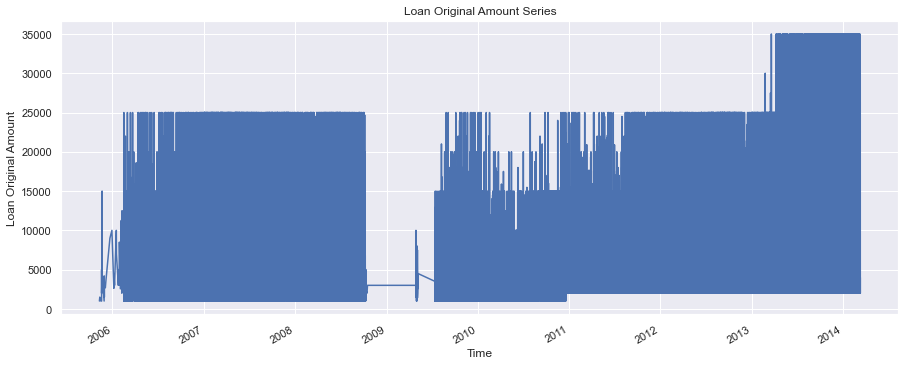

```python
# Plot raw time series of the original amount borrowed

fig, ax = plt.subplots(figsize=(15, 6))
prosper_dataset["LoanOriginalAmount"].plot(xlabel="Time", ylabel="Loan Original Amount", title="Loan Original Amount Series", ax=ax);
```

There are a lot missing values in our dataset, and for us to have a meaningful time series plot, we need to find a way to fill in this values. Since we are interested in the general distribution of the data, we will resample our data to the either weekly or monthly averages and visualize.

```python
prosper_dataset["LoanOriginalAmount"].resample("1W").mean().isnull().sum()
```

```
37
```

```python
prosper_dataset["LoanOriginalAmount"].resample("1M").mean().isnull().sum()
```

```
6
```

In order to cater for the missing data points, we will use the forward fill method

```python
# Average amount borrowed weekly

prosper_dataset["LoanOriginalAmount"].resample("1W").mean().fillna(method="ffill").to_frame()
```

| ListingCreationDate | LoanOriginalAmount |
| --- | --- |
| 2005-11-13 | 1250.0000 |
| 2005-11-20 | 4027.2727 |
| 2005-11-27 | 4000.0000 |
| 2005-12-04 | 2564.8333 |
| 2005-12-11 | 3500.0000 |
| ... | ... |
| 2014-02-16 | 11811.3439 |
| 2014-02-23 | 11981.4665 |
| 2014-03-02 | 12066.8385 |
| 2014-03-09 | 11957.3443 |
| 2014-03-16 | 10320.0000 |

436 rows × 1 columns

```python
# Average amount borrowed monthly

prosper_dataset["LoanOriginalAmount"].resample("1M").mean().fillna(method="ffill").to_frame()
```

| ListingCreationDate | LoanOriginalAmount |
| --- | --- |
| 2005-11-30 | 3342.1053 |
| 2005-12-31 | 6296.7500 |
| 2006-01-31 | 4962.0000 |
| 2006-02-28 | 5774.4298 |
| 2006-03-31 | 4782.1673 |
| ... | ... |
| 2013-11-30 | 11148.7404 |
| 2013-12-31 | 11800.6394 |
| 2014-01-31 | 11863.5759 |
| 2014-02-28 | 12000.4169 |
| 2014-03-31 | 11835.9887 |

101 rows × 1 columns

```python
# Function to plot a time series
def plot_time_series(data, series, sample, xlabel, ylabel, title):
    """
    data (DataFrame): the DataFrame
    series (series): the column to plot
    sample (str): the smaple window for the series. Options are Day (D), Week (W), Month (M), Year (Y)
    xlabel (str): label on the x-axis
    ylabel (str): label on the y-axis
    title (str): title of plot
    """
    fig, ax = plt.subplots(figsize=(15, 6))
    plot = data[series].resample(sample).mean().fillna(method="ffill").plot(ax=ax)
    plt.xlabel(xlabel)
    plt.ylabel(ylabel)
    plt.title(title)
    return plot
```

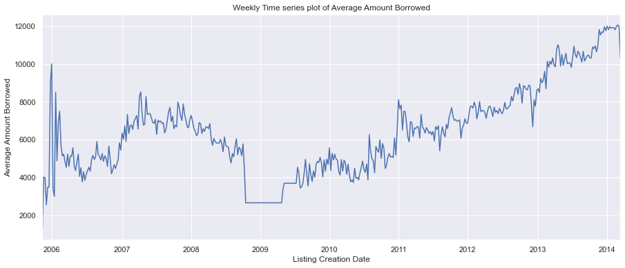

```python
# Plot time series of average amount borrowed weekly
plot_time_series(prosper_dataset, "LoanOriginalAmount", "1W",
                 "Listing Creation Date", "Average Amount Borrowed",
                 "Weekly Time series plot of Average Amount Borrowed");
```

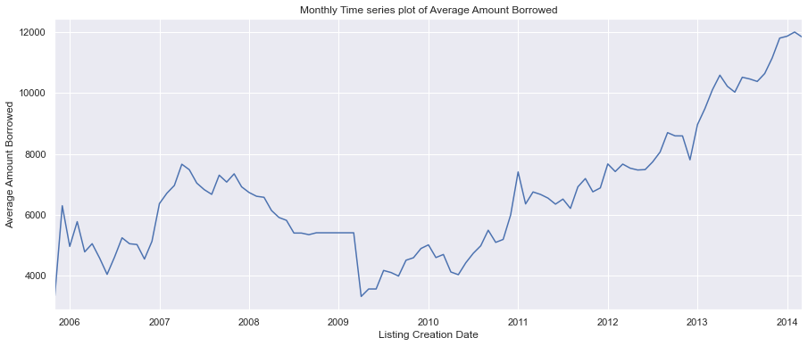

```python
# Plot time series of average amount borrowed monthly
plot_time_series(prosper_dataset, "LoanOriginalAmount", "1M",
                 "Listing Creation Date", "Average Amount Borrowed",
                 "Monthly Time series plot of Average Amount Borrowed");
```

Going by the trend, the average amount borrowed increased with each passing year, except for the dip which occured somewhere midway between the perios of the dataset, likely attributable to the fact there was somne missing points during this period.

#### Investigation 8: ListingCreationDate vs BorrowerRate

**Question:** What is the general trend of the borrower interest rate over the years?

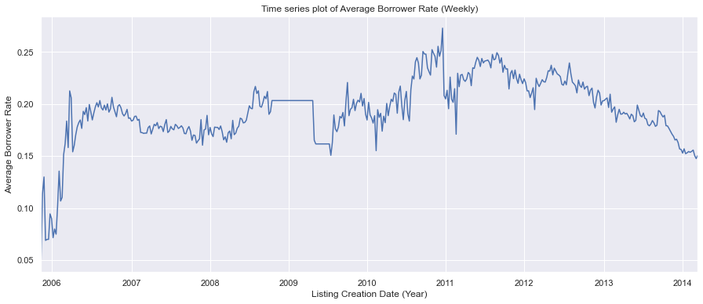

```python
# Plot timw series of borrower rate with a weekly sample window.
plot_time_series(prosper_dataset, "BorrowerRate", "1W",
                 "Listing Creation Date (Year)", "Average Borrower Rate",
                 "Time series plot of Average Borrower Rate (Weekly)");
```

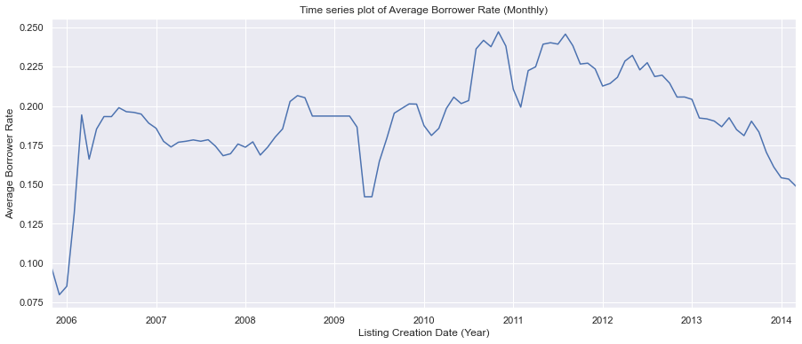

```python
# Plot timw series of borrower rate with a monthly sample window.
plot_time_series(prosper_dataset, "BorrowerRate", "1M",
                 "Listing Creation Date (Year)", "Average Borrower Rate",
                 "Time series plot of Average Borrower Rate (Monthly)");
```

The average borrower rate was relatively steady for the first half of the period covered, peaked around 2011, then dropped off again.

### Talk about some of the relationships you observed in this part of the investigation. How did the feature(s) of interest vary with other features in the dataset?

> - It appears that borrowers with prosper score ratings between 6 and 8 completed their loan payments, while the majority of those who defaulted or had their loans charged off had ratings between 5 and 6. The highest proportion of those who were still in the process of paying had a prosper score rating of 4.
> - There is no strong relationship between a borrower's income and how much they borrowed as loan, however, the data shows that mostly only low income earners (typically earning less than $50000) borrowed.
> - The higher a loan's rate/APR, the higher the chances of a defaulting, as seen from the above chart of loan status with APR/borrower rate.
> - There does not appear to be any significant difference between borrowers with homes and those without homes in the distribution of the loan statuses.

### Did you observe any interesting relationships between the other features (not the main feature(s) of interest)?

> It was interesting to see that home ownership did not really have much effect on the status of a loan, as the numbers were roughly equal between the two groups. It would have been natural to think that home owners would default a lot lesser than non home owners.